# *Mass invasions*: Temporal patterns for 13 Instagram vantage points¶

*▓▓▓▓▓▓▓ ▓▓▓▓▓▓▓, ▓▓▓▓▓▓▓, ▓▓▓▓▓▓▓ ▓▓▓▓▓▓▓ ▓▓▓▓▓▓▓; ▓▓▓▓▓▓▓ ▓▓▓▓▓▓▓, ▓▓▓▓▓▓▓ ▓▓▓▓▓▓▓ ▓▓▓▓▓▓▓, ▓▓▓▓▓▓▓*

[figure not shown]

•••

Last updated: Jul-11-2024, [Carto-Lab Docker](https://gitlab.vgiscience.de/lbsn/tools/jupyterlab) Version 0.14.0

Visualizations of temporal patterns for places affected by "mass invasion". The list of 13 places was prepared by Claudia Tautenhahn for her master's thesis.

> Tautenhahn, C. Das Phänomen der Masse: Landschaftliche Wirkungen sozialer Medien. Master's thesis. TU Dresden 2020, Department of Landscape Architecture and Environmental Planning

I was the second advisor of this thesis and performed data collection. Based on Claudia's list, 1.5 Million Instagram Posts were queried. The query period covered was `2010` to `2019`, but the lower analysis bound was limited to 2015 due to low data availability in early years. This notebook uses the originally collected data to create visualizations based on privacy-aware HyperLogLog cardinality estimation.

# Preparations

•••

```python
OUTPUT = Path.cwd().parents[0] / "out"       # output directory for figures (etc.)
WORK_DIR = Path.cwd().parents[0] / "tmp"     # Working directory
```

```python
OUTPUT.mkdir(exist_ok=True)
(OUTPUT / "figures").mkdir(exist_ok=True)
(OUTPUT / "svg").mkdir(exist_ok=True)
WORK_DIR.mkdir(exist_ok=True)
```

```python
%load_ext autoreload
%autoreload 2
```

Select `M` for monthly aggregation, `Y` for yearly aggregation

```python
AGG_BASE = "M"
```

First, define whether to study usercount or postcount

```python
# METRIC = 'user'
METRIC = 'post'
```

```python
metric_col = 'post_hll'
if METRIC == 'user':
    metric_col = 'user_hll'
```

Set global font

```python
plt.rcParams['font.family'] = 'serif'
plt.rcParams['font.serif'] = ['Times New Roman'] + plt.rcParams['font.serif']
```

```python
color_instagram = '#737EBD'
```

## Load HLL aggregate data

Load the data from CSV, generated in the previous notebook. Data is stored as aggregate HLL data (postcount, usercount) for each month.

•••

```python
%%time
data_files = {
    "MASS_INVASION_ALL":MASS_INVASION_ALL,
    }
tools.display_file_stats(data_files)
```

| name | MASS_INVASION_ALL |
| --- | --- |
| size | 2.03 MB |
| records | 735 |

```
CPU times: user 22.6 ms, sys: 3.36 ms, total: 25.9 ms
Wall time: 25.3 ms
```

```python
pd.read_csv(MASS_INVASION_ALL, nrows=10)
```

|  | year | month | post_hll | user_hll | topic_group |
| --- | --- | --- | --- | --- | --- |
| 0 | 2015 | 1 | \x138b400ec285429d01 | \x138b4037018fa19de2 | Bastei |
| 1 | 2015 | 1 | \x138b40022109420ba10cc11104154218421a811b031c... | \x138b4003e10481100110e11481162519e61ba21be31c... | Carrick-a-Rede |
| 2 | 2015 | 1 | \x138b40046105620ae10ec110251323146118e219a11d... | \x138b40032906840c0113a116411d81290133e435a13b... | Cliffs of Moher |
| 3 | 2015 | 1 | \x138b4002610ae10ba30ea215621e211e422c2236a338... | \x138b400921162521413943434243c145815361546355... | Dark Hedges |
| 4 | 2015 | 1 | \x138b401a42 | \x138b404561 | Fjadrargljufur |
| 5 | 2015 | 1 | \x138b4010e5b201f721 | \x138b4041817061d281 | Giant's Causeway |
| 6 | 2015 | 1 | \x138b400087058109810c8110e616e518611a411ba224... | \x138b40038107620b6116e318821a611bc21c22234326... | Lago di Braies |
| 7 | 2015 | 1 | \x138b4025812a2134c135823ea241845e8164e6762176... | \x138b4016a21d2251215a628de294419ec1a0e1aea1bd... | Preikestolen |
| 8 | 2015 | 1 | \x138b40074110611761184247c162c17381c001d501 | \x138b407762cbe2d582d8a1e341e361e622e822 | Trolltunga |
| 9 | 2015 | 1 | \x138b4008a11d8226433e825c035ec276a188038f219b... | \x138b4001c30d2211612ec22fe19b429e81c5c2f689f8... | Valle Verzasca |

## Connect hll worker db

```python
db_user = "postgres"
db_pass = os.getenv('POSTGRES_PASSWORD')
db_host = "127.0.0.1"
db_port = "25432"
db_name = "hlldb"
```

Connect to empty Postgres database running HLL Extension:

```python
DB_CONN = psycopg2.connect(
        host=db_host,
        port=db_port,
        dbname=db_name,
        user=db_user,
        password=db_pass
)
DB_CONN.set_session(
    readonly=True)
DB_CALC = tools.DbConn(
    DB_CONN)
CUR_HLL = DB_CONN.cursor()
```

test

# Calculate HLL Cardinality per month and year

Define additional functions for reading and formatting CSV as `pd.DataFrame`

```python
from datetime import datetime

def read_csv_datetime(csv: Path) -> pd.DataFrame:
    """Read CSV with parsing datetime index (months)

        First CSV column: Year
        Second CSV column: Month
    """
    date_cols = ["year", "month"]
    df = pd.read_csv(
        csv, index_col='datetime',
        parse_dates={'datetime':date_cols},
        date_format='%Y %m',
        keep_date_col='False')
    df.drop(columns=date_cols, inplace=True)
    return df

def append_cardinality_df(df: pd.DataFrame, hll_col: str = "post_hll", cardinality_col: str = 'postcount_est'):
    """Calculate cardinality from HLL and append to extra column in df"""
    df[cardinality_col] = df.apply(
        lambda x: hll.cardinality_hll(
           x[hll_col], CUR_HLL),
        axis=1)
    df.drop(columns=[hll_col], inplace=True)
    return df

def filter_fill_time(
        df: pd.DataFrame, min_year: int,
        max_year: int, val_col: str = "postcount_est",
        min_month: str = "01", max_month: str = "01", agg_base: str = None,
        agg_method = None):
    """Filter time values between min - max year and fill missing values"""
    max_day = "01"
    if agg_base is None:
        agg_base = "M"
    elif agg_base == "Y":
        max_month = "12"
        max_day = "31"
    min_date = pd.Timestamp(f'{min_year}-{min_month}-01')
    max_date = pd.Timestamp(f'{max_year}-{max_month}-{max_day}')
    # clip by start and end date
    if not min_date in df.index:
        df.loc[min_date, val_col] = 0
    if not max_date in df.index:
        df.loc[max_date, val_col] = 0
    df.sort_index(inplace=True)
    # mask min and max time
    time_mask = ((df.index >= min_date) & (df.index <= max_date))
    resampled = df.loc[time_mask][val_col].resample(agg_base)
    if agg_method is None:
        series = resampled.sum()
    elif agg_method == "count":
        series = resampled.count()
    elif agg_method == "nunique":
        series = resampled.nunique()
    # fill missing months with 0
    # this will also set the day to max of month
    return series.fillna(0).to_frame()
```

**Select dataset to process below**

Apply functions to all data sets.

```python
def process_dataset(
        dataset: Path = None, metric: str = None, df_post: pd.DataFrame = None,
        min_year: int = None, max_year: int = None, agg_base: str = None) -> pd.DataFrame:
    """Apply temporal filter/pre-processing to all data sets."""
    if metric is None:
        metric = 'post_hll'
        warn(f"Using default value {metric}")
    if metric == 'post_hll':
        cardinality_col = 'postcount_est'
    else:
        cardinality_col = 'usercount_est'
    if min_year is None:
        min_year = 2015
    if max_year is None:
        max_year = 2019
    if df_post is None:
        df_post = read_csv_datetime(dataset)
    df_post = append_cardinality_df(df_post, metric, cardinality_col)
    return filter_fill_time(df_post, min_year, max_year, cardinality_col, agg_base=agg_base)
```

```python
%%time
df_post = process_dataset(MASS_INVASION_ALL, agg_base=AGG_BASE, metric='post_hll')
```

```
CPU times: user 46.6 ms, sys: 4.72 ms, total: 51.4 ms
Wall time: 156 ms
```

```python
df_post.head(5)
```

| datetime | postcount_est |
| --- | --- |
| 2015-01-31 | 349 |
| 2015-02-28 | 368 |
| 2015-03-31 | 493 |
| 2015-04-30 | 547 |
| 2015-05-31 | 825 |

```python
%%time
df_user = process_dataset(MASS_INVASION_ALL, metric=metric_col, agg_base=AGG_BASE)
```

```
CPU times: user 42.9 ms, sys: 19.2 ms, total: 62.1 ms
Wall time: 170 ms
```

```python
df_user.head(5)
```

| datetime | postcount_est |
| --- | --- |
| 2015-01-31 | 349 |
| 2015-02-28 | 368 |
| 2015-03-31 | 493 |
| 2015-04-30 | 547 |
| 2015-05-31 | 825 |

# Visualize Cardinality

Define plot function.

```python
def fill_plot_time(
        df: pd.DataFrame, ax: Axes, color: str,
        label: str, val_col: str = "postcount_est") -> Axes:
    """Matplotlib Barplot with time axis formatting

    If "significant" in df columns, applies different colors to fill/edge
    of non-significant values.
    """
    if color is None:
        colors = sns.color_palette("vlag", as_cmap=True, n_colors=2)
        color_rgba = colors([1.0])[0]
        color = mcolor.rgb2hex((color_rgba), keep_alpha=True)
    color_significant = color
    color_significant_edge = "white"
    if "significant" in df.columns:
        colors_bar = {True: color, False: "white"}
        color_significant = df['significant'].replace(colors_bar)
        colors_edge = {True: "white", False: "black"}
        color_significant_edge = df['significant'].replace(colors_edge)
    df_plot = df.set_index(
        df.index.map(lambda s: s.strftime('%Y')))
    ax = df_plot.plot(
            ax=ax, y=val_col, color=color_significant,
            label=label, linewidth=0.5, alpha=0.6)
    ax.fill_between(range(len(df_plot.index)), df_plot[val_col], facecolor=color, alpha=0.6)
    return ax

def plot_time(
        df: Tuple[pd.DataFrame, pd.DataFrame], title, color = None, filename = None,
        output = OUTPUT, legend: str = "Postcount", val_col: str = None,
        trend: bool = None, seasonal: bool = None, residual: bool = None,
        agg_base: str = None, fig = None, ax = None, return_fig_ax = None):
    """Create dataframe(s) time plot"""
    x_ticks_every = 12
    fig_x = 10
    fig_y = 2
    font_mod = True
    x_label = "Year"
    linewidth = 3
    if agg_base and agg_base == "Y":
        x_ticks_every = 1
        fig_x = 3
        fig_y = 1.5
        font_mod = True
        x_label = "Year"
        linewidth = 1
    if fig is None or ax is None:
        fig, ax = plt.subplots()
        fig.set_size_inches(fig_x, fig_y)
    ylabel = f'{legend}'
    if val_col is None:
        val_col = f'{legend.lower()}_est'
    ax = fill_plot_time(
        df=df, ax=ax, color=color, val_col=val_col, label=legend)

    # TODO: below is a bit hacky way to format the x-axis;
    tick_loc = mticker.MultipleLocator(x_ticks_every)
    ax.xaxis.set_major_locator(tick_loc)
    ax.tick_params(axis='x', rotation=45, length=0.5)
    ax.yaxis.set_major_formatter(mticker.StrMethodFormatter('{x:,.0f}'))
    xrange_min_max = range(2015, 2021)
    with warnings.catch_warnings():
        warnings.simplefilter("ignore")
        ax.set_xticklabels(xrange_min_max, rotation=45)

    ax.set(xlabel=x_label, ylabel=ylabel)
    ax.spines["left"].set_linewidth(0.25)
    ax.spines["bottom"].set_linewidth(0.25)
    ax.spines["top"].set_linewidth(0)
    ax.spines["right"].set_linewidth(0)
    ax.yaxis.set_tick_params(width=0.5)
    # remove legend
    ax.get_legend().remove()
    ax.set_title(title)
    ax.set_xlim(-0.5, len(df)-0.5)
    ax.set_ylim(bottom=0)
    if font_mod:
        for item in (
            [ax.xaxis.label, ax.title, ax.yaxis.label] +
             ax.get_xticklabels() + ax.get_yticklabels()):
                item.set_fontsize(8)
    # store figure to file
    if filename:
        fig.savefig(
            output / "figures" / f"{filename}.png", dpi=300, format='PNG',
            bbox_inches='tight', pad_inches=1, facecolor="white")
        # also save as svg
        fig.savefig(
            output / "svg" / f"{filename}.svg", format='svg',
            bbox_inches='tight', pad_inches=1, facecolor="white")
    if return_fig_ax:
        return fig, ax
```

```python
def load_and_plot(
        dataset: Path = None, metric: str = None, src_ref: str = "flickr", colors: cm.colors.ListedColormap = None,
        agg_base: str = None, trend: bool = None, return_df: bool = None, df_post: pd.DataFrame = None, return_fig_ax = None):
    """Load data and plot"""
    if metric is None:
        metric = 'post_hll'
    if metric == 'post_hll':
        metric_label = 'postcount'
    else:
        metric_label = 'usercount'
    if colors is None:
        colors = sns.color_palette("vlag", as_cmap=True, n_colors=2)
        colors = colors([1.0])
    df = process_dataset(dataset, metric=metric, agg_base=agg_base, df_post=df_post)
    fig, ax = plot_time(
        df, legend=metric_label.capitalize(), color=colors,
        title=f'{src_ref}',
        filename=f"temporal_{metric_label}_{src_ref}_absolute", trend=trend, agg_base=agg_base, return_fig_ax=True)
    fig.show()
    if return_fig_ax:
        return fig, ax
    if return_df:
        return df
```

```python
colors = sns.color_palette("vlag", as_cmap=True, n_colors=2)
```

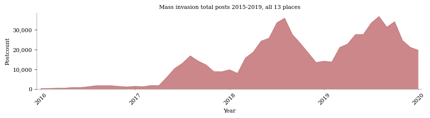

```python
fig, ax = load_and_plot(MASS_INVASION_ALL, src_ref=f"Mass invasion total posts 2015-2019, all 13 places", agg_base=AGG_BASE, trend=False, metric=metric_col, return_fig_ax=True)
fig.show()
```

## Visualize individual places

### Monthly

```python
df = pd.read_csv(MASS_INVASION_ALL)
df.tail()
```

|  | year | month | post_hll | user_hll | topic_group |
| --- | --- | --- | --- | --- | --- |
| 729 | 2019 | 10 | \x138b40018101c3032109e20b810c210fa2114512e114... | \x138b4000c10442054107e20a41108113a114c515a716... | Rakotzbrücke |
| 730 | 2019 | 10 | \x138b40004400820161048104c304e20661078108a108... | \x138b4000610241028103a105e706a1072107a207c207... | Trolltunga |
| 731 | 2019 | 10 | \x138b4000240081020503c106e407e1084109620a020a... | \x138b4000a1012102c103a20403044105c10721084108... | Valle Verzasca |
| 732 | 2019 | 11 | \x148b4000040000600000000020008250000100000080... | \x148b4000401180410880000400004400000000020000... | Bastei |
| 733 | 2019 | 11 | \x138b40004104e206c2120115e118881c221ec4216122... | \x138b4007a20ae20f621164128113e123e2304241614f... | Cliffs of Moher |

```python
mass_invasion_places = df['topic_group'].unique()
```

```python
mass_invasion_places
```

```
array(['Bastei', 'Carrick-a-Rede', 'Cliffs of Moher', 'Dark Hedges',
       'Fjadrargljufur', "Giant's Causeway", 'Lago di Braies',
       'Preikestolen', 'Trolltunga', 'Valle Verzasca', 'Obersee',
       'Rakotzbrücke', 'Hängebrücke Geierlay'], dtype=object)
```

```python
def plot_bars(
        df: pd.DataFrame, ax: matplotlib.axes = None, title: str = None):
    """Plot bars from two DataFrames"""
    bar_param = {
        "width":1.0,
        "label":"Mass invasion total post count aggregated for months",
        "edgecolor":"white",
        "linewidth":0.5,
        "alpha":1.0
    }
    # create figure
    if not ax:
        fig, ax = plt.subplots(1, 1, figsize=(3, 1.5))
    # plot
    df.groupby(df.index.month)["postcount_est"] \
        .mean().plot.bar(ax=ax, color=color_instagram, y="postcount_est", **bar_param)
    # format
    ax.set_xlim(-0.5,11.5)
    month_names = ['Jan','Feb','Mar','Apr','May','Jun',
                   'Jul','Aug','Sep','Oct','Nov','Dec']
    ax.set_xticklabels(month_names)
    ax.tick_params(axis='x', rotation=45, length=0) # length: of ticks
    ax.spines["left"].set_linewidth(0.25)
    ax.spines["bottom"].set_linewidth(0.25)
    ax.spines["top"].set_linewidth(0)
    ax.spines["right"].set_linewidth(0)
    ax.yaxis.set_tick_params(width=0.5)
    ax.set(xlabel="", ylabel="")
    if not title:
        title = "Post Count per Month (mean)"
    ax.set_title(title, y=-0.2, pad=-14)
    for item in (
        [ax.xaxis.label, ax.title, ax.yaxis.label] +
         ax.get_xticklabels() + ax.get_yticklabels()):
            item.set_fontsize(8)
```

```python
top_50_cnt = 13
top_50 = mass_invasion_places.tolist()
```

```python
top_50.sort()
```

```python
top_50
```

```
['Bastei',
 'Carrick-a-Rede',
 'Cliffs of Moher',
 'Dark Hedges',
 'Fjadrargljufur',
 "Giant's Causeway",
 'Hängebrücke Geierlay',
 'Lago di Braies',
 'Obersee',
 'Preikestolen',
 'Rakotzbrücke',
 'Trolltunga',
 'Valle Verzasca']
```

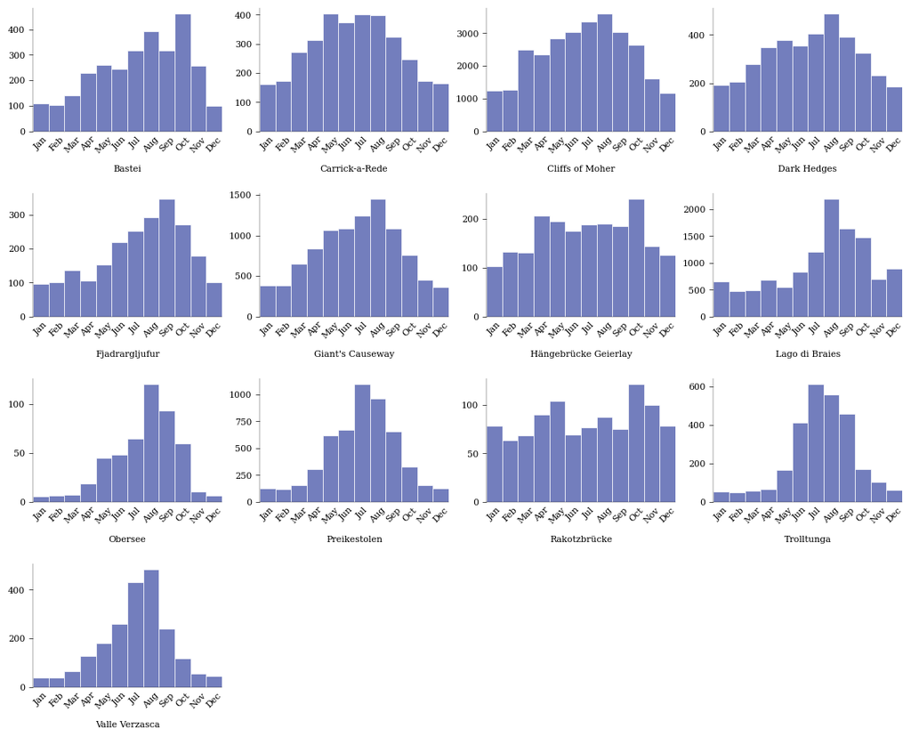

```python
df_post = read_csv_datetime(MASS_INVASION_ALL)
# create figure object with multiple subplots
fig, axes = plt.subplots(nrows=int(top_50_cnt/3), ncols=4, figsize=(14, 11))
fig.subplots_adjust(hspace=.5) # adjust vertical space, to allow title below plot
# iterate places
for ix, ax in enumerate(axes.reshape(-1)):
    if ix >= len(top_50):
        ax.set_axis_off()
        continue
    np_str = top_50[ix]
    # filter np_str and calculate cardinality
    df_post_filter = df_post[df_post["topic_group"]==np_str].copy()
    df_post_filter = append_cardinality_df(df_post_filter, 'post_hll', 'postcount_est')
    df_post_filter = filter_fill_time(df_post_filter, 2010, 2023, 'postcount_est')
    # plot bars individually
    plot_bars(
        df=df_post_filter, title=np_str, ax=ax)
```

```python
tools.save_fig(fig, output=OUTPUT, name="barplot_massinvasion_seasonal")
```

### Yearly

```python
def bar_plot_time(
        df: pd.DataFrame, ax: Axes, color: str,
        label: str, val_col: str = "postcount_est") -> Axes:
    """Matplotlib Barplot with time axis formatting

    If "significant" in df columns, applies different colors to fill/edge
    of non-significant values.
    """
    if color is None:
        color = color_instagram
    color_significant = color
    color_significant_edge = "white"
    if "significant" in df.columns:
        colors_bar = {True: color, False: "white"}
        color_significant = df['significant'].replace(colors_bar)
        colors_edge = {True: "white", False: "black"}
        color_significant_edge = df['significant'].replace(colors_edge)
    bar_param = {
        "width":1.0,
        "label":label,
        "edgecolor":"white",
        "linewidth":0.5,
        "alpha":1.0
    }
    ax = df.set_index(
         df.index.map(lambda s: s.strftime('%Y'))).plot.bar(
            ax=ax, color=color_instagram, y="postcount_est", **bar_param)
    return ax

def plot_time(
        df: Tuple[pd.DataFrame, pd.DataFrame], title, color = None, filename = None,
        output = OUTPUT, legend: str = "Postcount", val_col: str = None,
        trend: bool = None, seasonal: bool = None, residual: bool = None,
        agg_base: str = None, ax = None):
    """Create dataframe(s) time plot"""
    x_ticks_every = 12
    fig_x = 15.7
    fig_y = 4.27
    font_mod = False
    x_label = ""
    linewidth = 3
    if agg_base and agg_base == "Y":
        x_ticks_every = 1
        fig_x = 3
        fig_y = 1.5
        font_mod = True
        x_label = ""
        linewidth = 1
    if ax is None:
        fig, ax = plt.subplots()
        fig.set_size_inches(fig_x, fig_y)
    ylabel = ""
    if val_col is None:
        val_col = f'{legend.lower()}_est'
    ax = bar_plot_time(
        df=df, ax=ax, color=color, val_col=val_col, label=legend)
    # format
    tick_loc = mticker.MultipleLocator(x_ticks_every)
    ax.xaxis.set_major_locator(tick_loc)
    ax.tick_params(axis='x', rotation=45, length=0)
    ax.yaxis.set_major_formatter(mticker.StrMethodFormatter('{x:,.0f}'))
    ax.set(xlabel=x_label, ylabel=ylabel)
    ax.spines["left"].set_linewidth(0.25)
    ax.spines["bottom"].set_linewidth(0.25)
    ax.spines["top"].set_linewidth(0)
    ax.spines["right"].set_linewidth(0)
    ax.yaxis.set_tick_params(width=0.5)
    # remove legend
    ax.get_legend().remove()
    ax.set_title(title, y=-0.2, pad=-14)
    ax.set_xlim(-0.5,len(df)-0.5)
    for item in (
        [ax.xaxis.label, ax.title, ax.yaxis.label] +
         ax.get_xticklabels() + ax.get_yticklabels()):
            item.set_fontsize(8)
```

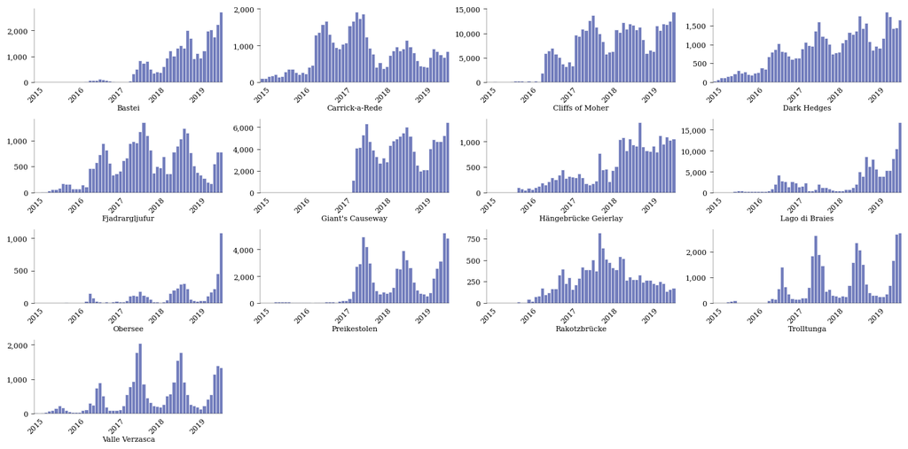

```python
df_post = read_csv_datetime(MASS_INVASION_ALL)
# create figure object with multiple subplots
fig, axes = plt.subplots(nrows=int(top_50_cnt/3), ncols=4, figsize=(17, 8))
fig.subplots_adjust(hspace=.5) # adjust vertical space, to allow title below plot
# iterate places
for ix, ax in enumerate(axes.reshape(-1)):
    if ix >= len(top_50):
        ax.set_axis_off()
        continue
    np_str = top_50[ix]
    # filter np_str and calculate cardinality
    df_post_filter = df_post[df_post["topic_group"]==np_str].copy()
    df_post_filter = append_cardinality_df(df_post_filter, 'post_hll', 'postcount_est')
    df_post_filter = filter_fill_time(df_post_filter, 2015, 2019, 'postcount_est', max_month=8)
    # plot bars individually
    plot_time(
        df=df_post_filter, title=np_str, ax=ax)
```

```python
tools.save_fig(fig, output=OUTPUT, name="barplot_massinvasion_trend")
```

# Create notebook HTML

```python
!jupyter nbconvert --to html_toc \
    --output-dir=../resources/html/ ./01_mass_invasion.ipynb \
    --output 04_mass_invasion \
    --template=../nbconvert.tpl \
    --ExtractOutputPreprocessor.enabled=False >&- 2>&-
```